# Multiple Regression and CANDY!!!

```r
library(tidyverse)
library(skimr)
library(moderndive)
library(fivethirtyeight)
```

In this session, we’ll look at some candy data form fivethirtyeight.com. Source: https://fivethirtyeight.com/videos/the-ultimate-halloween-candy-power-ranking/

“winpercent” - how often did a candy win a matchup (e.g., ) “sugarpercent” - how mucu sugar does it have “chocolate” - whether it contains chocolate or not

# Part 0: data exploration - go through the data and plot winpercent on sugarpercent with a categrocial variable chocolate

```r
# get the data from fivethirtyeight library
candy <- candy_rankings
```

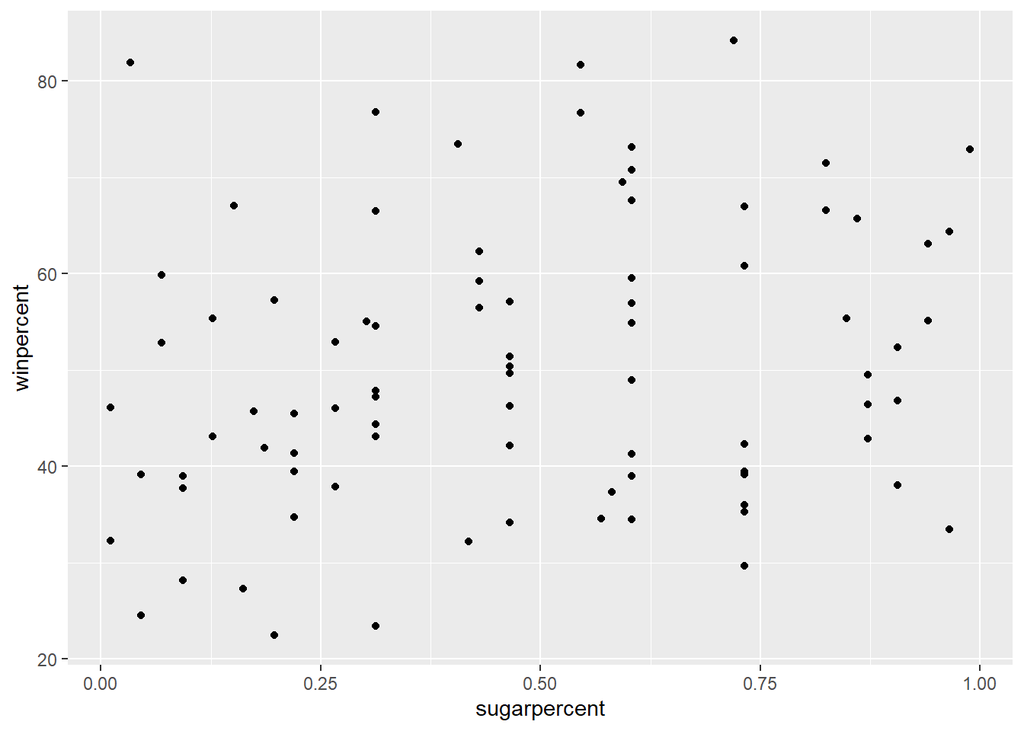

```r
# scatter plot without categories
ggplot() +
    geom_point(data = candy,  aes(x = sugarpercent, y = winpercent))
```

```r
# scatter plot with categories
ggplot() +
    geom_point(data = candy,  aes(x = sugarpercent, y = winpercent, color=chocolate))
```

## Exercise 1: where is my fitted regression line(s)?

From the textbook, there are two ways to introduce fitted regression lines: * `geom_smooth(method = "lm", se = FALSE)` * `geom_parallel_slopes(se=FALSE)` We show two failed attempts below. Can you figure out why?

```r
# These two lines produce a scatter plot.
# Add the two options, one at a time.
ggplot() +
    geom_point(data = candy,  aes(x = sugarpercent, y = winpercent, color=chocolate))
```

### Why nothing happened here?

```r
ggplot() +
    geom_point(data = candy,  aes(x = sugarpercent, y = winpercent, color=chocolate))  +
    geom_smooth(method = "lm", se = FALSE)
```

```r
ggplot() +
    geom_point(data = candy,  aes(x = sugarpercent, y = winpercent, color=chocolate))  +
    geom_parallel_slopes(se=FALSE)
```

### Here is the plots that works:

#### Fitting the models with different intercepts and different slopes

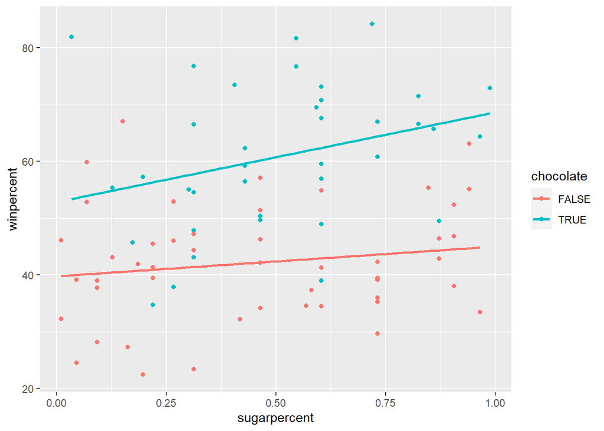

```r
# add code to draw the regression line with method = lm
candy %>%
    ggplot(aes(x = sugarpercent, y = winpercent, color=chocolate)) +
    geom_point() +
    geom_smooth(method = "lm", se = FALSE)
```

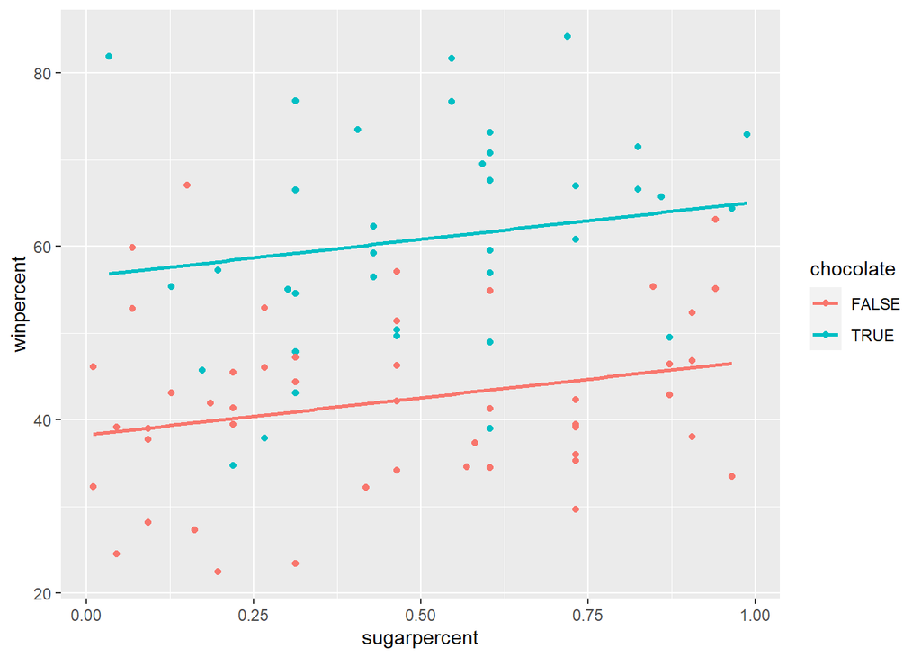

```r
# add code to draw the regression line using parallel slopes
 ggplot(data = candy, aes(x = sugarpercent, y = winpercent, color=chocolate)) +
    geom_point() +
    geom_parallel_slopes(se=FALSE)
```

# Part 1: y on x1, y on x2(cat);

```r
lm_fit_simple_binary = lm(winpercent ~ chocolate, data=candy)
get_regression_table(lm_fit_simple_binary)
```

```
## # A tibble: 2 x 7
##   term          estimate std_error statistic p_value lower_ci upper_ci
##   <chr>            <dbl>     <dbl>     <dbl>   <dbl>    <dbl>    <dbl>
## 1 intercept         42.1      1.65     25.6        0     38.9     45.4
## 2 chocolateTRUE     18.8      2.50      7.52       0     13.8     23.7
```

```r
lm_fit_simple_conti = lm(winpercent ~ sugarpercent, data=candy)
get_regression_table(lm_fit_simple_conti)
```

```
## # A tibble: 2 x 7
##   term         estimate std_error statistic p_value lower_ci upper_ci
##   <chr>           <dbl>     <dbl>     <dbl>   <dbl>    <dbl>    <dbl>
## 1 intercept        44.6      3.09     14.5    0       38.5       50.7
## 2 sugarpercent     11.9      5.56      2.14   0.035    0.866     23.0
```

# Part 2: y on x1 and x2, with different model specifications (but consistent interpretation)

Here are two linear models each estimating one plot we drew above.

```r
# parallel slopes model
lm1 = lm(winpercent ~ chocolate + sugarpercent, data=candy)
get_regression_table(lm1)
```

```
## # A tibble: 3 x 7
##   term          estimate std_error statistic p_value lower_ci upper_ci
##   <chr>            <dbl>     <dbl>     <dbl>   <dbl>    <dbl>    <dbl>
## 1 intercept        38.3       2.55     15.0    0       33.2       43.3
## 2 chocolateTRUE    18.3       2.47      7.40   0       13.4       23.2
## 3 sugarpercent      8.57      4.36      1.97   0.053   -0.096     17.2
```

```r
# interaction model
lm2 = lm(winpercent ~ chocolate * sugarpercent, data=candy)
get_regression_table(lm2)
```

```
## # A tibble: 4 x 7
##   term                    estimate std_error statistic p_value lower_ci upper_ci
##   <chr>                      <dbl>     <dbl>     <dbl>   <dbl>    <dbl>    <dbl>
## 1 intercept                  39.8       2.88    13.8     0        34.1      45.5
## 2 chocolateTRUE              13.1       5.23     2.50    0.015     2.64     23.5
## 3 sugarpercent                5.22      5.26     0.993   0.324    -5.24     15.7
## 4 chocolateTRUE:sugarper~    10.6       9.35     1.13    0.261    -8.02     29.2
```

## Exercise 2-1: write down the model using the numbers in the estimate column

lm_1 equation: winpercent = 38.262 + 18.273*chocolate + 8.567*sugarpercent

By `lm1`, `winpercent ~ chocolate + sugarpercent`, note, the slope for sugarpercent has `p-value` > 0.05, meaning that its slope is not significantly different from 0.

lm_2 equation: winpercent = 39.778 + 13.051*chocolate + 5.221*sugarpercent + 10.586*chocolate*sugarpercent

By `lm2`, `winpercent ~ chocolate * sugarpercent`, note, here, the coefficient for sugarpercent (5.221) and the coefficient for the interaction term `chocolateTRUE:sugarpercent` (10.586) are both not significantly different from 0 as the `p value` is >0.05.

## Exercise 2-2: plot the estimated regression line in the scatter plot

### For the parallel slope model

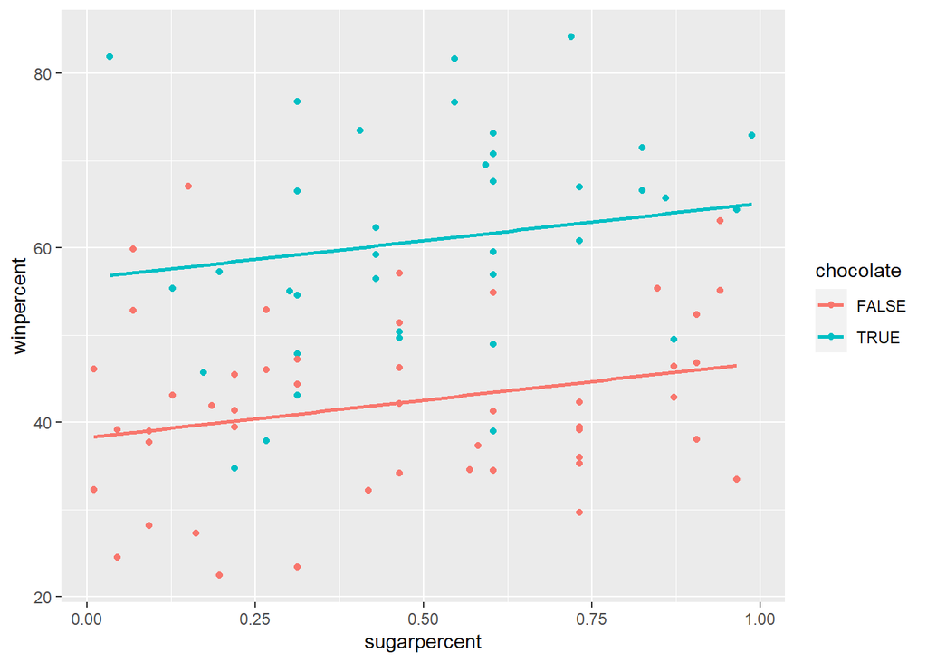

```r
candy %>%
    ggplot(aes(x = sugarpercent, y = winpercent, color=chocolate)) +
    geom_point() +
    geom_parallel_slopes(se=FALSE)
```

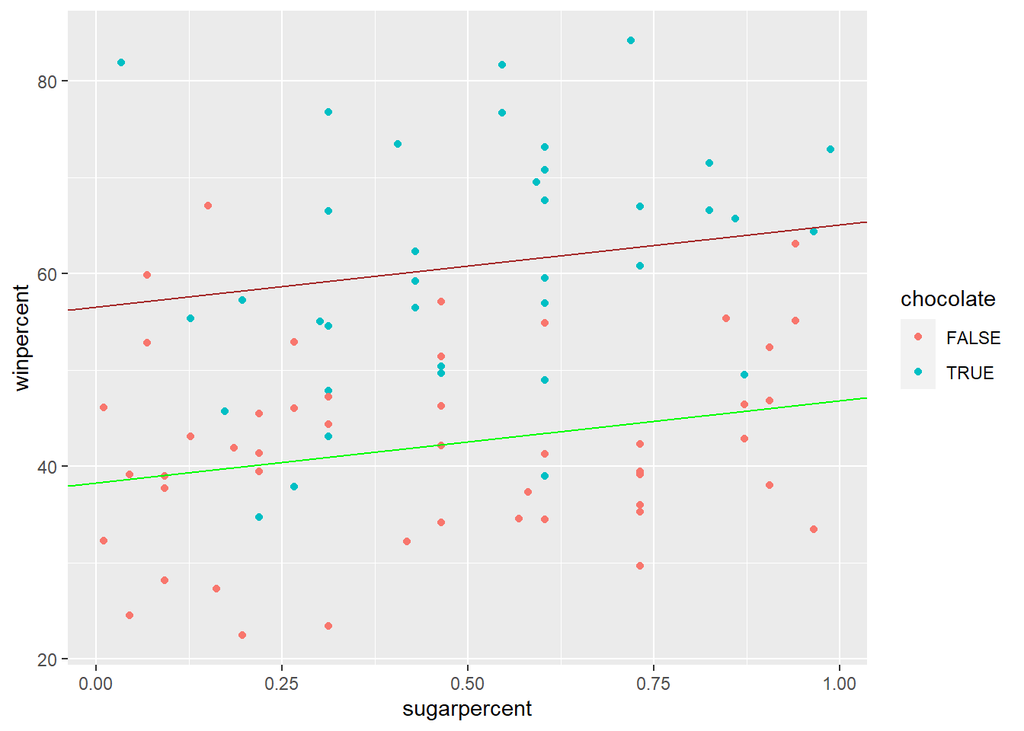

```r
candy %>%
    ggplot(aes(x = sugarpercent, y = winpercent, color=chocolate)) +
    geom_point() +
    geom_abline(intercept = 38.26, slope = 8.567, color='green') +
    geom_abline(intercept = 38.26 + 18.273, slope = 8.567, color='brown')
```

### For the linear regression with interaction term

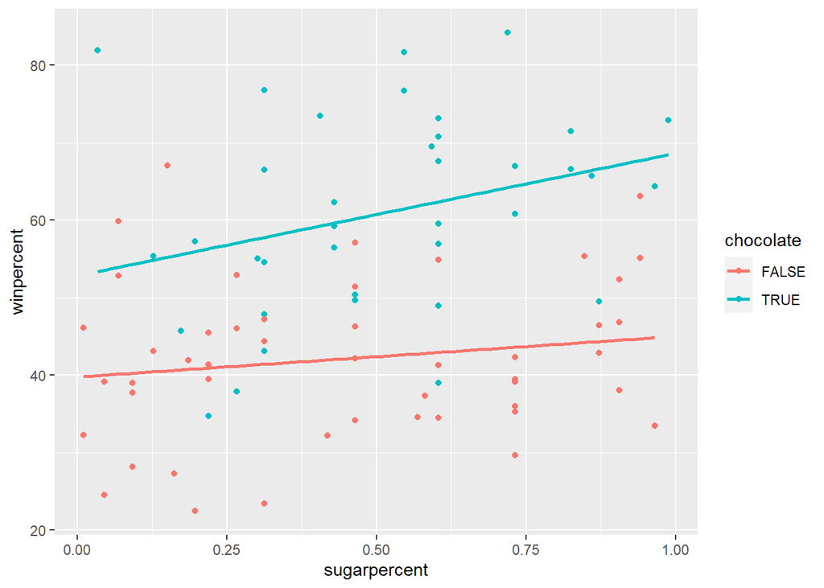

```r
candy %>%
    ggplot(aes(x = sugarpercent, y = winpercent, color=chocolate)) +
    geom_point() +
    geom_smooth(method='lm', se=FALSE)
```

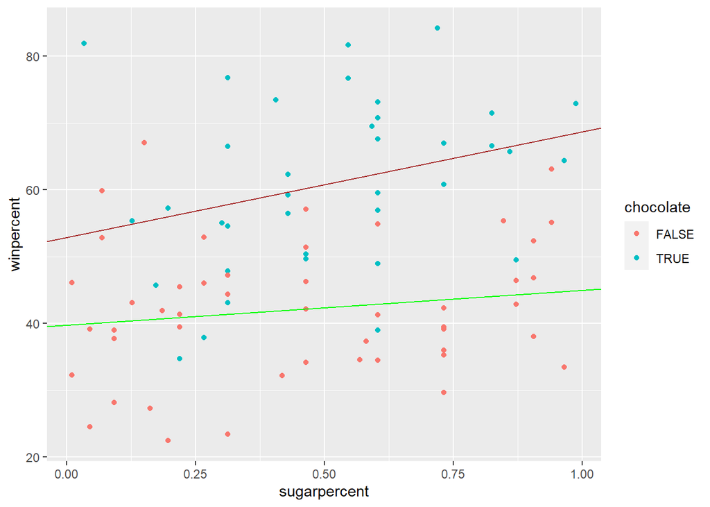

```r
candy %>%
    ggplot(aes(x = sugarpercent, y = winpercent, color=chocolate)) +
    geom_point() +
    geom_abline(intercept = 39.778, slope = 5.221, color='green') +
    geom_abline(intercept = 39.778 +  13.051, slope = 5.221 + 10.586, color='brown')
```

## Questions

1. What should we do when we have coefficients that are not significant? If it’s not significant, drop it. 1.1 drop them from the equation? Yes, drop it if it’s not significant. 1.2 drop them from the model? Yes, drop it if it’s not significant.

## Detour 1: all possible and different R-specifications for the same model

```r
lm2_alternative = lm(winpercent ~ chocolate + chocolate * sugarpercent, data=candy)
get_regression_table(lm2_alternative)
```

```
## # A tibble: 4 x 7
##   term                    estimate std_error statistic p_value lower_ci upper_ci
##   <chr>                      <dbl>     <dbl>     <dbl>   <dbl>    <dbl>    <dbl>
## 1 intercept                  39.8       2.88    13.8     0        34.1      45.5
## 2 chocolateTRUE              13.1       5.23     2.50    0.015     2.64     23.5
## 3 sugarpercent                5.22      5.26     0.993   0.324    -5.24     15.7
## 4 chocolateTRUE:sugarper~    10.6       9.35     1.13    0.261    -8.02     29.2
```

```r
# get_regression_summaries(lm2_alternative)
```

```r
lm2_alternative2 = lm(winpercent ~ chocolate + sugarpercent+ chocolate * sugarpercent, data=candy)
get_regression_table(lm2_alternative2)
```

```
## # A tibble: 4 x 7
##   term                    estimate std_error statistic p_value lower_ci upper_ci
##   <chr>                      <dbl>     <dbl>     <dbl>   <dbl>    <dbl>    <dbl>
## 1 intercept                  39.8       2.88    13.8     0        34.1      45.5
## 2 chocolateTRUE              13.1       5.23     2.50    0.015     2.64     23.5
## 3 sugarpercent                5.22      5.26     0.993   0.324    -5.24     15.7
## 4 chocolateTRUE:sugarper~    10.6       9.35     1.13    0.261    -8.02     29.2
```

```r
# get_regression_summaries(lm2_alternative2)
```

```r
lm2_alternative3 = lm(winpercent ~ sugarpercent + chocolate * sugarpercent, data=candy)
get_regression_table(lm2_alternative3)
```

```
## # A tibble: 4 x 7
##   term                    estimate std_error statistic p_value lower_ci upper_ci
##   <chr>                      <dbl>     <dbl>     <dbl>   <dbl>    <dbl>    <dbl>
## 1 intercept                  39.8       2.88    13.8     0        34.1      45.5
## 2 sugarpercent                5.22      5.26     0.993   0.324    -5.24     15.7
## 3 chocolateTRUE              13.1       5.23     2.50    0.015     2.64     23.5
## 4 sugarpercent:chocolate~    10.6       9.35     1.13    0.261    -8.02     29.2
```

```r
# get_regression_summaries(lm2_alternative3)
```

```r
lm2_alternative4 = lm(winpercent ~ sugarpercent + chocolate + chocolate:sugarpercent, data=candy)
get_regression_table(lm2_alternative4)
```

```
## # A tibble: 4 x 7
##   term                    estimate std_error statistic p_value lower_ci upper_ci
##   <chr>                      <dbl>     <dbl>     <dbl>   <dbl>    <dbl>    <dbl>
## 1 intercept                  39.8       2.88    13.8     0        34.1      45.5
## 2 sugarpercent                5.22      5.26     0.993   0.324    -5.24     15.7
## 3 chocolateTRUE              13.1       5.23     2.50    0.015     2.64     23.5
## 4 sugarpercent:chocolate~    10.6       9.35     1.13    0.261    -8.02     29.2
```

## Part 3: bonus - to dump all variables in a linear regression model

```r
lm_all = lm(winpercent ~ ., data = candy[, -1])
get_regression_table(lm_all)
```

```
## # A tibble: 12 x 7
##    term                 estimate std_error statistic p_value lower_ci upper_ci
##    <chr>                   <dbl>     <dbl>     <dbl>   <dbl>    <dbl>    <dbl>
##  1 intercept              34.5        4.32     7.99    0        25.9    43.1
##  2 chocolateTRUE          19.7        3.90     5.07    0        12.0    27.5
##  3 fruityTRUE              9.42       3.76     2.50    0.015     1.92   16.9
##  4 caramelTRUE             2.22       3.66     0.608   0.545    -5.07    9.51
##  5 peanutyalmondyTRUE     10.1        3.62     2.78    0.007     2.86   17.3
##  6 nougatTRUE              0.804      5.72     0.141   0.888   -10.6    12.2
##  7 crispedricewaferTRUE    8.92       5.27     1.69    0.095    -1.58   19.4
##  8 hardTRUE               -6.16       3.46    -1.78    0.079   -13.1     0.721
##  9 barTRUE                 0.442      5.06     0.087   0.931    -9.64   10.5
## 10 pluribusTRUE           -0.854      3.04    -0.281   0.779    -6.91    5.20
## 11 sugarpercent            9.09       4.66     1.95    0.055    -0.2    18.4
## 12 pricepercent           -5.93       5.51    -1.08    0.286   -16.9     5.06
```